# Covariance Structure Selection Workflow

Choosing Between UN, CS, AR(1), and Random Effects

## 1. Available Structures

The following table summarizes the most commonly used covariance structures for longitudinal data:

| Structure | Parameters | Matrix Pattern | When to Use |
| --- | --- | --- | --- |
| **Independence** | $n$ | Diagonal | Baseline comparison; rarely realistic |
| **Compound Symmetry (CS)** | 2 | Equal correlation at all lags | Exchangeable observations; clustered data |
| **AR(1)** | 2 | Correlation decays with lag | Equally spaced time points; decaying dependence |
| **Exponential** | 2 | Continuous-time decay | Unequally spaced observations |
| **Unstructured (UN)** | $n(n+1)/2$ | Any pattern allowed | Exploratory; few time points |
| **Random Intercept** | 2 | Induces CS pattern | Subject heterogeneity; induces correlation |
| **Random Intercept + Slope** | 4 | Nonstationary covariance | Time-varying subject effects |

### Mathematical Formulations

**Independence:**
$$\boldsymbol{R} = \sigma^2 \boldsymbol{I}$$

**Compound Symmetry (CS):**
$$R_{jk} = \sigma^2 \begin{cases} 1 & \text{if } j = k \\ \rho & \text{if } j \neq k \end{cases}$$

**AR(1):**
$$R_{jk} = \sigma^2 \rho^{|j-k|}$$

**Exponential (continuous time):**
$$R_{jk} = \sigma^2 \exp\left(-\frac{|t_j - t_k|}{\phi}\right)$$

**Unstructured (UN):**
$$R_{jk} = \sigma_{jk} \quad \text{(all elements estimated freely)}$$

## 2. Visual Pattern Gallery

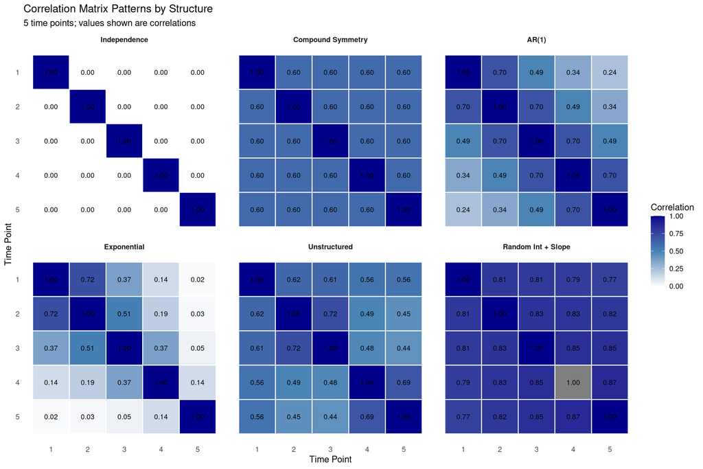

Figure 1: Correlation matrices for different covariance structures

```r
# Function to create correlation matrix for different structures
create_corr_matrix <- function(n, type, params = list()) {
  mat <- matrix(0, n, n)

  if (type == "Independence") {
    mat <- diag(n)
  } else if (type == "CS") {
    rho <- params$rho
    mat <- matrix(rho, n, n)
    diag(mat) <- 1
  } else if (type == "AR1") {
    rho <- params$rho
    for (i in 1:n) {
      for (j in 1:n) {
        mat[i, j] <- rho^abs(i - j)
      }
    }
  } else if (type == "Exponential") {
    phi <- params$phi
    times <- params$times
    for (i in 1:n) {
      for (j in 1:n) {
        mat[i, j] <- exp(-abs(times[i] - times[j]) / phi)
      }
    }
  } else if (type == "UN") {
    # Generate a positive definite "random" unstructured matrix
    set.seed(667)
    A <- matrix(runif(n * n, 0.2, 0.8), n, n)
    mat <- (A + t(A)) / 2
    diag(mat) <- 1
    # Ensure positive definite
    eigenvals <- eigen(mat)$values
    if (any(eigenvals <= 0)) {
      mat <- mat + diag(n) * (abs(min(eigenvals)) + 0.1)
      mat <- cov2cor(mat)
    }
  } else if (type == "Random Intercept") {
    # Induces CS: Corr = sigma_b^2 / (sigma_b^2 + sigma_e^2)
    rho <- params$rho
    mat <- matrix(rho, n, n)
    diag(mat) <- 1
  } else if (type == "Random Slope") {
    # Nonstationary covariance
    sigma_b0 <- params$sigma_b0
    sigma_b1 <- params$sigma_b1
    sigma_e <- params$sigma_e
    rho_b <- params$rho_b
    times <- 1:n
    for (i in 1:n) {
      for (j in 1:n) {
        cov_ij <- sigma_b0^2 + rho_b * sigma_b0 * sigma_b1 * (times[i] + times[j]) +
                  sigma_b1^2 * times[i] * times[j]
        if (i == j) cov_ij <- cov_ij + sigma_e^2
        mat[i, j] <- cov_ij
      }
    }
    # Convert to correlation
    sds <- sqrt(diag(mat))
    mat <- mat / outer(sds, sds)
  }

  return(mat)
}

# Create all correlation matrices
n <- 5
times_irreg <- c(0, 1, 3, 6, 12)  # Irregular time points

corr_list <- list(
  "Independence" = create_corr_matrix(n, "Independence"),
  "Compound Symmetry" = create_corr_matrix(n, "CS", list(rho = 0.6)),
  "AR(1)" = create_corr_matrix(n, "AR1", list(rho = 0.7)),
  "Exponential" = create_corr_matrix(n, "Exponential", list(phi = 3, times = times_irreg)),
  "Unstructured" = create_corr_matrix(n, "UN"),
  "Random Int + Slope" = create_corr_matrix(n, "Random Slope",
                                             list(sigma_b0 = 2, sigma_b1 = 0.3,
                                                  sigma_e = 1, rho_b = 0.2))
)

# Convert to long format for plotting
plot_data <- do.call(rbind, lapply(names(corr_list), function(name) {
  mat <- corr_list[[name]]
  data.frame(
    Structure = name,
    Row = rep(1:n, each = n),
    Col = rep(1:n, n),
    Correlation = as.vector(mat)
  )
}))

# Set factor levels for ordering
plot_data$Structure <- factor(plot_data$Structure,
                               levels = c("Independence", "Compound Symmetry",
                                          "AR(1)", "Exponential",
                                          "Unstructured", "Random Int + Slope"))

# Create heatmap
ggplot(plot_data, aes(x = Col, y = Row, fill = Correlation)) +
  geom_tile(color = "white", linewidth = 0.5) +
  geom_text(aes(label = sprintf("%.2f", Correlation)), size = 3, color = "black") +
  facet_wrap(~Structure, ncol = 3) +
  scale_fill_gradient2(low = "white", mid = "steelblue", high = "darkblue",
                       midpoint = 0.5, limits = c(0, 1)) +
  scale_y_reverse() +
  labs(x = "Time Point", y = "Time Point",
       title = "Correlation Matrix Patterns by Structure",
       subtitle = "5 time points; values shown are correlations") +
  theme_minimal(base_size = 11) +
  theme(panel.grid = element_blank(),
        strip.text = element_text(face = "bold"),
        axis.text = element_text(size = 9))
```

### Key Features by Structure

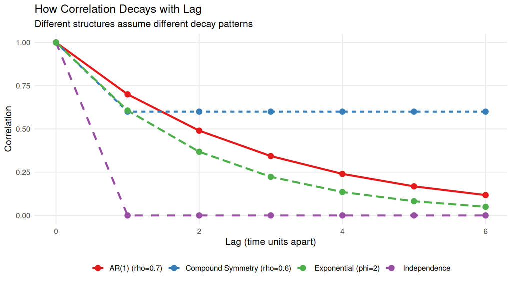

Figure 2: Correlation decay patterns across structures

```r
# Create decay curves
lag <- 0:6
rho <- 0.7

decay_data <- data.frame(
  Lag = rep(lag, 4),
  Structure = rep(c("Independence", "Compound Symmetry (rho=0.6)",
                    "AR(1) (rho=0.7)", "Exponential (phi=2)"), each = length(lag)),
  Correlation = c(
    c(1, rep(0, 6)),           # Independence
    c(1, rep(0.6, 6)),         # CS
    0.7^lag,                    # AR(1)
    exp(-lag/2)                 # Exponential
  )
)

ggplot(decay_data, aes(x = Lag, y = Correlation, color = Structure, linetype = Structure)) +
  geom_line(linewidth = 1.2) +
  geom_point(size = 3) +
  scale_color_brewer(palette = "Set1") +
  scale_y_continuous(limits = c(0, 1)) +
  labs(x = "Lag (time units apart)",
       y = "Correlation",
       title = "How Correlation Decays with Lag",
       subtitle = "Different structures assume different decay patterns") +
  theme_minimal(base_size = 12) +
  theme(legend.position = "bottom",
        legend.title = element_blank(),
        panel.grid.minor = element_blank())
```

## 3. Selection Flowchart

Use the following decision tree as a starting point for selecting a covariance structure:

```
START
  v
How many time points (n)?
  +---> n <= 4: Unstructured (UN) may be feasible
  |              --> Compare UN to simpler structures
  +---> n > 4: UN has too many parameters
                v
          Are time points equally spaced?
                +---> Yes: Consider AR(1) or CS
                |          |
                |          v
                |     Expect correlation to decay with lag?
                |          |
                |          +---> Yes: AR(1)
                |          +---> No (constant correlation): CS
                +---> No (irregular spacing):
                           v
                      Exponential or spatial correlation
                      OR use random effects model
                v
          Is there subject-level heterogeneity?
                +---> Yes: Add random intercept (possibly random slope)
                +---> No: Marginal model with chosen correlation
                v
          DIAGNOSTIC CHECK
                +---> Plot residual semivariogram
                +---> Compare AIC/BIC across structures
                +---> LRT for nested models
                v
          SELECT FINAL MODEL
```

### Visual Decision Aid

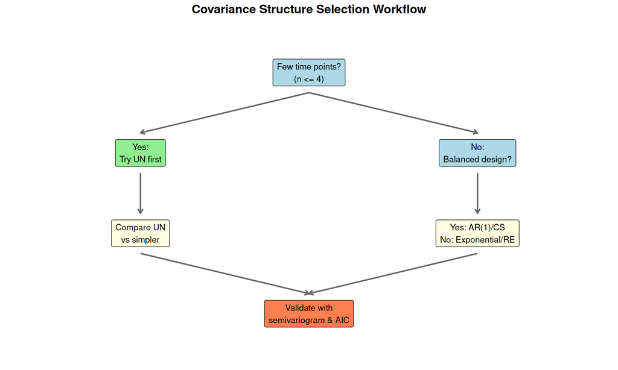

Figure 3: Covariance structure selection decision guide

## 4. Parameter Count Table

The number of parameters in the covariance matrix grows differently across structures:

```r
# Create parameter count table
n_visits <- c(3, 4, 5, 6, 8, 10, 15, 20)

param_table <- data.frame(
  `Time Points` = n_visits,
  Independence = n_visits,
  CS = rep(2, length(n_visits)),
  `AR(1)` = rep(2, length(n_visits)),
  Unstructured = n_visits * (n_visits + 1) / 2,
  `Random Intercept` = rep(2, length(n_visits)),
  `Random Int+Slope` = rep(4, length(n_visits)),
  check.names = FALSE
)

kable(param_table, align = "c",
      caption = "Number of covariance parameters needed")
```

Table 1: Number of covariance parameters by structure and number of time points

Number of covariance parameters needed

| Time Points | Independence | CS | AR(1) | Unstructured | Random Intercept | Random Int+Slope |
| --- | --- | --- | --- | --- | --- | --- |
| 3 | 3 | 2 | 2 | 6 | 2 | 4 |
| 4 | 4 | 2 | 2 | 10 | 2 | 4 |
| 5 | 5 | 2 | 2 | 15 | 2 | 4 |
| 6 | 6 | 2 | 2 | 21 | 2 | 4 |
| 8 | 8 | 2 | 2 | 36 | 2 | 4 |
| 10 | 10 | 2 | 2 | 55 | 2 | 4 |
| 15 | 15 | 2 | 2 | 120 | 2 | 4 |
| 20 | 20 | 2 | 2 | 210 | 2 | 4 |

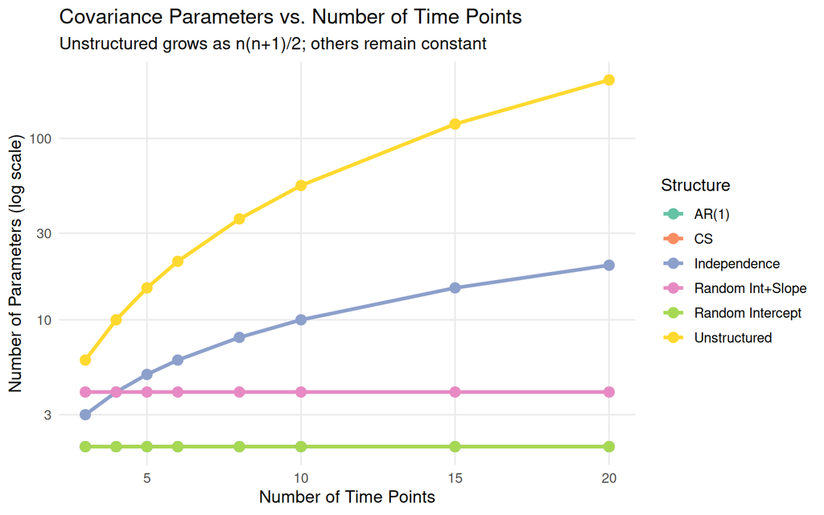

Figure 4: Parameter count explosion with Unstructured covariance

```r
param_long <- param_table |>
  pivot_longer(cols = -`Time Points`, names_to = "Structure", values_to = "Parameters")

ggplot(param_long, aes(x = `Time Points`, y = Parameters, color = Structure)) +
  geom_line(linewidth = 1.2) +
  geom_point(size = 3) +
  scale_y_log10() +
  scale_color_brewer(palette = "Set2") +
  labs(x = "Number of Time Points",
       y = "Number of Parameters (log scale)",
       title = "Covariance Parameters vs. Number of Time Points",
       subtitle = "Unstructured grows as n(n+1)/2; others remain constant") +
  theme_minimal(base_size = 12) +
  theme(legend.position = "right",
        panel.grid.minor = element_blank())
```

**Key Insight:** With 10 time points, Unstructured requires 55 parameters versus only 2 for AR(1) or CS. This quickly becomes infeasible with limited sample sizes.

## 5. Model Comparison Protocol

Follow this systematic approach to select the optimal covariance structure:

### Step 1: Fit the Maximal Mean Model

Establish the fixed effects structure first (using REML is acceptable here for initial fitting).

### Step 2: Fit Multiple Covariance Structures

Keep the **same fixed effects** and vary only the covariance structure.

### Step 3: Use REML for Comparison

When comparing covariance structures with **identical fixed effects**, REML provides unbiased variance estimates.

### Step 4: Compare AIC/BIC

Lower values indicate better fit, accounting for model complexity.

### Step 5: Check Residual Semivariogram

A flat semivariogram near 1 indicates properly modeled correlation.

### Step 6: Likelihood Ratio Test for Nested Structures

CS is nested within UN, so you can use LRT to test whether UN significantly improves fit.

```r
# Protocol implementation example
# Step 1: Fit maximal mean model with different covariance structures

# Independence (baseline)
fit_indep <- gls(y ~ time * treatment, data = mydata,
                 method = "REML")

# Compound Symmetry
fit_cs <- gls(y ~ time * treatment, data = mydata,
              correlation = corCompSymm(form = ~ 1 | subject),
              method = "REML")

# AR(1)
fit_ar1 <- gls(y ~ time * treatment, data = mydata,
               correlation = corAR1(form = ~ time | subject),
               method = "REML")

# Unstructured
fit_un <- gls(y ~ time * treatment, data = mydata,
              correlation = corSymm(form = ~ 1 | subject),
              weights = varIdent(form = ~ 1 | time),
              method = "REML")

# Step 4: Compare AIC/BIC
AIC(fit_indep, fit_cs, fit_ar1, fit_un)
BIC(fit_indep, fit_cs, fit_ar1, fit_un)

# Step 6: LRT for nested models (CS within UN)
anova(fit_cs, fit_un)
```

## 6. R Code Examples

### Simulated Dataset

```r
set.seed(667)

# Simulate longitudinal data with AR(1) correlation
n_subjects <- 60
n_times <- 5
times <- 1:n_times

# Generate data
sim_data <- expand.grid(
  time = times,
  subject = 1:n_subjects
) |>
  arrange(subject, time) |>
  mutate(
    treatment = factor(ifelse(subject <= n_subjects/2, "Control", "Treatment"))
  )

# Add AR(1) correlated errors
phi_true <- 0.6
sigma_true <- 2

sim_data <- sim_data |>
  group_by(subject) |>
  mutate(
    # Random intercept
    b0 = rnorm(1, 0, 2)[1],
    # AR(1) errors
    error = {
      e <- numeric(n())
      e[1] <- rnorm(1, 0, sigma_true)
      for (t in 2:n()) {
        e[t] <- phi_true * e[t-1] + rnorm(1, 0, sigma_true * sqrt(1 - phi_true^2))
      }
      e
    },
    # Outcome with treatment effect
    y = 20 + 2 * time +
        ifelse(treatment == "Treatment", 3 + 0.5 * time, 0) +
        b0 + error
  ) |>
  ungroup() |>
  select(subject, time, treatment, y)

sim_data$subject <- factor(sim_data$subject)

head(sim_data, 10)
```

```
# A tibble: 10 × 4
   subject  time treatment     y
   <fct>   <int> <fct>     <dbl>
 1 1           1 Control    19.4
 2 1           2 Control    23.8
 3 1           3 Control    25.4
 4 1           4 Control    28.5
 5 1           5 Control    28.6
 6 2           1 Control    25.3
 7 2           2 Control    26.5
 8 2           3 Control    31.6
 9 2           4 Control    30.1
10 2           5 Control    33.1
```

### Fit All Structures

```r
# 1. Independence
fit_indep <- gls(y ~ time * treatment,
                 data = sim_data,
                 method = "REML")

# 2. Compound Symmetry
fit_cs <- gls(y ~ time * treatment,
              data = sim_data,
              correlation = corCompSymm(form = ~ 1 | subject),
              method = "REML")

# 3. AR(1)
fit_ar1 <- gls(y ~ time * treatment,
               data = sim_data,
               correlation = corAR1(form = ~ time | subject),
               method = "REML")

# 4. Unstructured
fit_un <- gls(y ~ time * treatment,
              data = sim_data,
              correlation = corSymm(form = ~ 1 | subject),
              weights = varIdent(form = ~ 1 | time),
              method = "REML")

# 5. Random Intercept Model (for comparison)
fit_ri <- lme(y ~ time * treatment,
              data = sim_data,
              random = ~ 1 | subject,
              method = "REML")

# 6. Random Intercept + AR(1) residuals
fit_ri_ar1 <- lme(y ~ time * treatment,
                  data = sim_data,
                  random = ~ 1 | subject,
                  correlation = corAR1(form = ~ time | subject),
                  method = "REML")
```

### Create Comparison Table

```r
# Extract comparison metrics
comparison <- data.frame(
  Model = c("Independence", "Compound Symmetry", "AR(1)",
            "Unstructured", "Random Intercept", "RI + AR(1)"),
  AIC = c(AIC(fit_indep), AIC(fit_cs), AIC(fit_ar1),
          AIC(fit_un), AIC(fit_ri), AIC(fit_ri_ar1)),
  BIC = c(BIC(fit_indep), BIC(fit_cs), BIC(fit_ar1),
          BIC(fit_un), BIC(fit_ri), BIC(fit_ri_ar1)),
  logLik = c(logLik(fit_indep), logLik(fit_cs), logLik(fit_ar1),
             logLik(fit_un), logLik(fit_ri), logLik(fit_ri_ar1))
)

# Add delta AIC
comparison$deltaAIC <- comparison$AIC - min(comparison$AIC)

# Round for display
comparison[, 2:5] <- round(comparison[, 2:5], 2)

kable(comparison, align = "lrrrr",
      col.names = c("Model", "AIC", "BIC", "Log-Likelihood", "Delta AIC"))
```

Table 2: Model comparison for covariance structure selection

| Model | AIC | BIC | Log-Likelihood | Delta AIC |
| --- | --- | --- | --- | --- |
| Independence | 1524.52 | 1542.97 | -757.26 | 246.62 |
| Compound Symmetry | 1304.12 | 1326.26 | -646.06 | 26.22 |
| AR(1) | 1284.85 | 1307.00 | -636.43 | 6.96 |
| Unstructured | 1289.70 | 1359.81 | -625.85 | 11.80 |
| Random Intercept | 1304.12 | 1326.26 | -646.06 | 26.22 |
| RI + AR(1) | 1277.90 | 1303.73 | -631.95 | 0.00 |

### Visualize Estimated Correlation Matrices

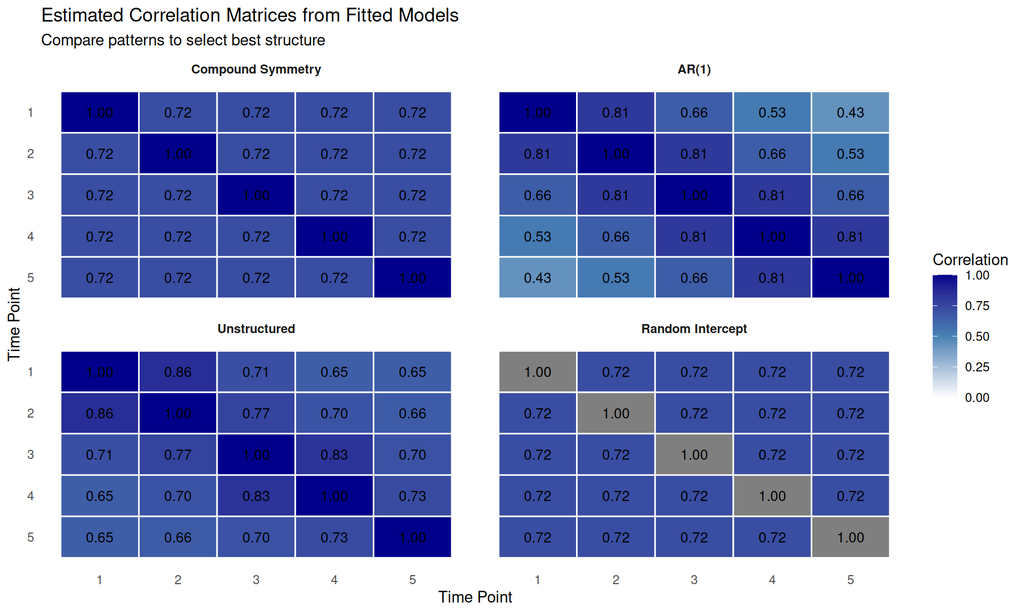

Figure 5: Estimated correlation matrices from fitted models

```r
# Extract estimated correlation matrices
extract_corr <- function(fit, n = 5) {
  if (inherits(fit, "gls")) {
    if (is.null(fit$modelStruct$corStruct)) {
      return(diag(n))
    }
    corr_mat <- corMatrix(fit$modelStruct$corStruct)[[1]]
  } else if (inherits(fit, "lme")) {
    # For mixed models, need to extract from random effects
    vc <- getVarCov(fit, type = "marginal")[[1]]
    sds <- sqrt(diag(vc))
    corr_mat <- vc / outer(sds, sds)
  }
  return(corr_mat[1:n, 1:n])
}

# Get correlation matrices
corr_cs <- extract_corr(fit_cs)
corr_ar1 <- extract_corr(fit_ar1)
corr_un <- extract_corr(fit_un)
corr_ri <- extract_corr(fit_ri)

# Combine for plotting
est_corr_list <- list(
  "Compound Symmetry" = corr_cs,
  "AR(1)" = corr_ar1,
  "Unstructured" = corr_un,
  "Random Intercept" = corr_ri
)

est_plot_data <- do.call(rbind, lapply(names(est_corr_list), function(name) {
  mat <- est_corr_list[[name]]
  data.frame(
    Structure = name,
    Row = rep(1:nrow(mat), each = ncol(mat)),
    Col = rep(1:ncol(mat), nrow(mat)),
    Correlation = as.vector(mat)
  )
}))

est_plot_data$Structure <- factor(est_plot_data$Structure,
                                   levels = names(est_corr_list))

ggplot(est_plot_data, aes(x = Col, y = Row, fill = Correlation)) +
  geom_tile(color = "white", linewidth = 0.5) +
  geom_text(aes(label = sprintf("%.2f", Correlation)), size = 3.5, color = "black") +
  facet_wrap(~Structure, ncol = 2) +
  scale_fill_gradient2(low = "white", mid = "steelblue", high = "darkblue",
                       midpoint = 0.5, limits = c(0, 1)) +
  scale_y_reverse() +
  labs(x = "Time Point", y = "Time Point",
       title = "Estimated Correlation Matrices from Fitted Models",
       subtitle = "Compare patterns to select best structure") +
  theme_minimal(base_size = 11) +
  theme(panel.grid = element_blank(),
        strip.text = element_text(face = "bold"))
```

### Semivariogram Diagnostics

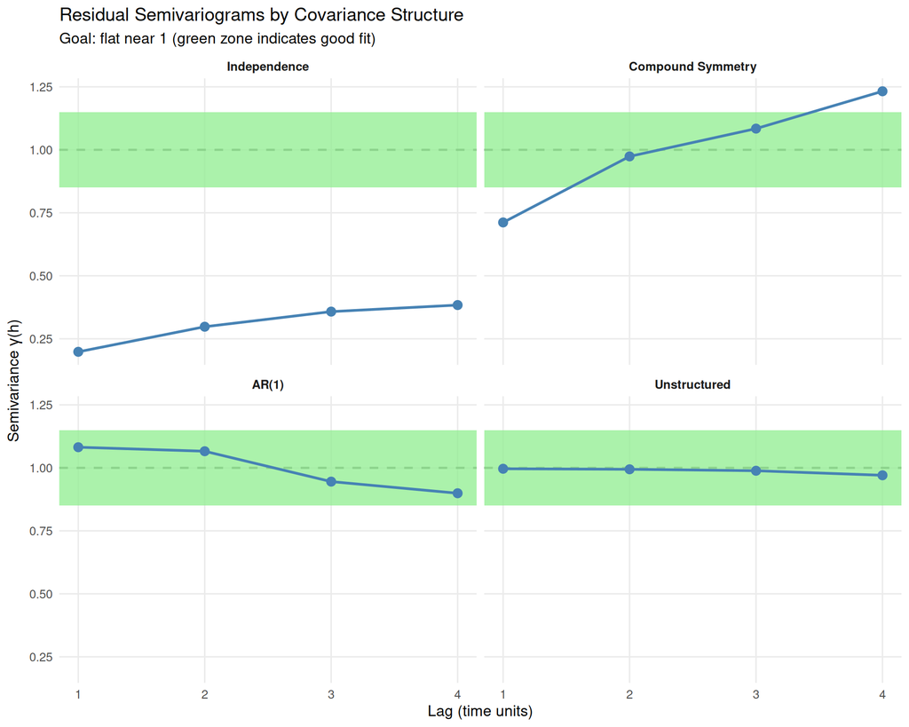

Figure 6: Residual semivariograms for model diagnostics

```r
# Extract semivariograms for gls models
vario_indep <- Variogram(fit_indep, form = ~ time | subject, resType = "normalized")
vario_cs <- Variogram(fit_cs, form = ~ time | subject, resType = "normalized")
vario_ar1 <- Variogram(fit_ar1, form = ~ time | subject, resType = "normalized")
vario_un <- Variogram(fit_un, form = ~ time | subject, resType = "normalized")

# Combine for plotting
vario_indep$Model <- "Independence"
vario_cs$Model <- "Compound Symmetry"
vario_ar1$Model <- "AR(1)"
vario_un$Model <- "Unstructured"

vario_all <- rbind(
  data.frame(vario_indep),
  data.frame(vario_cs),
  data.frame(vario_ar1),
  data.frame(vario_un)
)

vario_all$Model <- factor(vario_all$Model,
                           levels = c("Independence", "Compound Symmetry",
                                      "AR(1)", "Unstructured"))

ggplot(vario_all, aes(x = dist, y = variog)) +
  geom_hline(yintercept = 1, linetype = "dashed", color = "gray50", linewidth = 0.8) +
  geom_rect(aes(xmin = -Inf, xmax = Inf, ymin = 0.85, ymax = 1.15),
            fill = "lightgreen", alpha = 0.3) +
  geom_point(color = "steelblue", size = 3) +
  geom_line(color = "steelblue", linewidth = 1) +
  facet_wrap(~Model, ncol = 2) +
  labs(x = "Lag (time units)",
       y = expression(paste("Semivariance ", gamma, "(h)")),
       title = "Residual Semivariograms by Covariance Structure",
       subtitle = "Goal: flat near 1 (green zone indicates good fit)") +
  theme_minimal(base_size = 12) +
  theme(strip.text = element_text(face = "bold"),
        panel.grid.minor = element_blank())
```

### Interpretation of Semivariograms

- **Independence:** Rising pattern indicates unmodeled positive autocorrelation
- **Compound Symmetry:** Some improvement but may not fully capture decay
- **AR(1):** Flatter pattern if correctly specified
- **Unstructured:** Most flexible, but may overfit

### Likelihood Ratio Test for Nested Models

```r
# CS is nested within UN (test whether UN provides significant improvement)
cat("LRT: Compound Symmetry vs. Unstructured\n")
```

```
LRT: Compound Symmetry vs. Unstructured
```

```r
cat("H0: CS is adequate\n")
```

```
H0: CS is adequate
```

```r
cat("H1: UN provides significantly better fit\n\n")
```

```
H1: UN provides significantly better fit
```

```r
# Refit with ML for valid LRT
fit_cs_ml <- gls(y ~ time * treatment,
                 data = sim_data,
                 correlation = corCompSymm(form = ~ 1 | subject),
                 method = "ML")

fit_un_ml <- gls(y ~ time * treatment,
                 data = sim_data,
                 correlation = corSymm(form = ~ 1 | subject),
                 weights = varIdent(form = ~ 1 | time),
                 method = "ML")

# LRT
lrt_result <- anova(fit_cs_ml, fit_un_ml)
print(lrt_result)
```

```
          Model df      AIC      BIC    logLik   Test  L.Ratio p-value
fit_cs_ml     1  6 1299.031 1321.253 -643.5153
fit_un_ml     2 19 1285.488 1355.860 -623.7442 1 vs 2 39.54209   2e-04
```

## 7. Common Mistakes

### Mistake 1: Using UN with Too Many Time Points

```r
# BAD: Trying UN with 15 time points
# This requires 15*16/2 = 120 covariance parameters!
fit_bad <- gls(y ~ time * treatment,
               data = mydata_15visits,
               correlation = corSymm(form = ~ 1 | subject),
               weights = varIdent(form = ~ 1 | time),
               method = "REML")
# Will likely fail to converge or produce unstable estimates

# GOOD: Use AR(1) or random effects instead
fit_good <- lme(y ~ time * treatment,
                random = ~ 1 | subject,
                correlation = corAR1(form = ~ time | subject),
                data = mydata_15visits,
                method = "REML")
```

### Mistake 2: Comparing ML vs REML Fitted Models

```r
# BAD: Comparing models fit with different methods
fit_cs_reml <- gls(y ~ ..., method = "REML")
fit_ar1_ml <- gls(y ~ ..., method = "ML")
AIC(fit_cs_reml, fit_ar1_ml)  # INVALID comparison!

# GOOD: Use same method for all models being compared
fit_cs <- gls(y ~ ..., method = "REML")
fit_ar1 <- gls(y ~ ..., method = "REML")
AIC(fit_cs, fit_ar1)  # Valid comparison
```

### Mistake 3: Ignoring Convergence Warnings

```r
# Always check for convergence!
# If you see warnings like:
# "iteration limit reached"
# "Hessian is not positive definite"
#
# DO NOT trust the results - try:
# 1. Simpler covariance structure
# 2. Better starting values
# 3. Different optimizer
# 4. Check for data issues (outliers, insufficient variation)
```

### Mistake 4: Over-parameterizing with Small Samples

**Rule of thumb:** Need approximately 10-20 observations per covariance parameter for stable estimation.

| Structure | Parameters (5 times) | Min Sample Size |
| --- | --- | --- |
| CS | 2 | 20-40 subjects |
| AR(1) | 2 | 20-40 subjects |
| UN | 15 | 150-300 subjects |

## 8. Quick Reference Card

### Situation-Based Recommendations

| Situation | Recommended Structure | Rationale |
| --- | --- | --- |
| Few time points (n <= 4), exploratory | UN | Can afford the parameters; most flexible |
| Regular visits, expect correlation decay | AR(1) | Parsimonious; captures decay pattern |
| Irregular visit times | Exponential | Handles unequal spacing |
| Clustered data (e.g., schools, clinics) | CS or Random Intercept | Exchangeable within cluster |
| Subject heterogeneity in trajectories | Random Intercept + Slope | Allows individual trends |
| Unknown pattern | Start with CS | Simple baseline; compare alternatives |
| Model comparison inconclusive | Random Intercept + AR(1) | Combines subject effects and serial correlation |

### nlme Function Reference

```r
# Correlation structures in gls()
corCompSymm(form = ~ 1 | subject)       # Compound symmetry
corAR1(form = ~ time | subject)         # AR(1)
corSymm(form = ~ 1 | subject)           # Unstructured correlation
corExp(form = ~ time | subject)         # Exponential
corGaus(form = ~ time | subject)        # Gaussian
corLin(form = ~ time | subject)         # Linear

# Heterogeneous variances
weights = varIdent(form = ~ 1 | time)   # Different variance per time
weights = varPower(form = ~ time)       # Variance as power of time

# Mixed models with correlation
lme(y ~ time,
    random = ~ 1 | subject,                    # Random intercept
    correlation = corAR1(form = ~ time | subject),  # Plus AR(1)
    data = mydata)
```

### Decision Checklist

Before finalizing your covariance structure:

- Checked number of parameters vs. sample size
- Fit multiple candidate structures with same fixed effects
- Used REML for all models being compared
- Compared AIC and BIC values
- Examined residual semivariograms
- Performed LRT for nested structures (if applicable)
- Checked convergence of all models
- Verified estimated parameters are reasonable (e.g., 0 < rho < 1)

## Summary

Selecting an appropriate covariance structure is crucial for valid inference in longitudinal data analysis:

1. **Start simple:** Begin with CS or AR(1) as baseline
2. **Consider the science:** What pattern of correlation makes biological/practical sense?
3. **Balance fit and parsimony:** UN fits better but costs more parameters
4. **Use diagnostics:** Semivariograms reveal unmodeled correlation
5. **Check assumptions:** Equal spacing for AR(1), sample size for UN
6. **Validate selection:** AIC/BIC and LRT provide statistical guidance

When in doubt, start with a parsimonious structure (CS or AR(1)) and add complexity only if diagnostics indicate poor fit.